# S8 RQ3: original vs (attritioned + imputed)

- Show All Code
- Hide All Code
- View Source

## Description

In this (non-preregistered) analysis, we look at variables collected at years 12 & 16 which have low levels of missingness, and test the effect of selecting only those who took part at year 21 and 26 time points (“attritioning”).

We compare ( original ) vs ( attritioned + imputed ) results across 200 multiply imputed datasets.

Imputation diagnostics (proportion of usable cases, fraction of missing information, convergence, correlations between the imputation variables) are in `8_rq6_4_imputation_diagnostics.qmd`.

## Load Data

```r
source("0_load_data_with_pgs.R")                                                # 0_load_data.R + the 12 PGS used as auxiliary variables (rq6z_pgs_vars)

df = df %>%
  filter(!(randomfamid %in% exclude_fams_rq1x)) %>%
  filter(!(randomfamid %in% exclude_fams_onesib)) %>%
  filter(!(randomfamid %in% exclude_fams_rq6y))

## range of participation outcomes to use for attrition

range_participation_outcomes = 6:9

# Subset vectors to only include participation outcomes in range
rq1y_twin                         = rq1y_twin[range_participation_outcomes]
rq1y_twin1                        = rq1y_twin1[range_participation_outcomes]
rq1y_twin2                        = rq1y_twin2[range_participation_outcomes]
rq1y_twin_labels                  = rq1y_twin_labels[range_participation_outcomes]
rq1y_twin_labels_clean            = rq1y_twin_labels_clean[range_participation_outcomes]
rq1y_twin_labels_clean_extrashort = rq1y_twin_labels_clean_extrashort[range_participation_outcomes]

boot_compare_results = readRDS(file.path("results",        "8_rq6_boot_compare_results.Rds"))
imputed_mice         = readRDS(file = file.path("results", "8_1_imputed_mice.Rds"))
tasks                = readRDS(file = file.path("results", "8_1_tasks.Rds")) %>%
  mutate(i = 1:nrow(.))

gc()

# Number of imputations per timepoint
n_imputations = length(boot_compare_results)/length(range_participation_outcomes)
```

### Focal Variables and timepoints

Attrition time points

```r
cbind(
  rq6y,
  rq6y_labels
) %>%
  knitr::kable(caption = "Outcome Variables")
```

Outcome Variables

| rq6y | rq6y_labels |
| --- | --- |
| lcmfqt1 | Y12: Depression (MFQ) |
| lsdqext1 | Y12: Externalising (SDQ) |
| lcg1 | Y12: Cognitive ability |
| pcexgcsecoregrdm1 | Y16: GCSE grade |

```r
cbind(
  rq1y_twin1,
  rq1y_twin_labels_clean
) %>%
  knitr::kable(caption = "Attrition time points")
```

Attrition time points

| rq1y_twin1 | rq1y_twin_labels_clean |
| --- | --- |
| u1cdata1 | Y21 (TEDS21 phase-1 questionnaire) |
| zmhdata1 | Y26 (TEDS26 questionnaire) |
| zcdata1 | Y26 (CATSLife web tests) |
| hasgeno1 | Genotyped |

### Table of all variables used in multiple imputation (RQ3)

Note that imputation was performed separately across zygosity-sex groups (i.e., MZ males, MZ females, DZ males, …) therefore sex and zygosity are omitted from imputation models.

Because imputations were performed separetely for each attriitoning time point, we calculate FMI for each timepoint and average across.

The table below lists every variable included in the multiple imputation models for RQ3, with its description, TEDS code, observed range/levels, percentage missing in the original sample, mean fraction of missing information (FMI) across timepoints, and study wave.

```r
# Function to map variable prefix to study wave
get_study_wave = function(var_name) {
  if (str_detect(var_name, "^pgs_")) return("Genotyping")                      # polygenic scores
  prefix = substr(var_name, 1, 1)
  wave_map = c(
    "a" = "1st Contact",
    "b" = "2 Year",
    "c" = "3 Year",
    "d" = "4 Year",
    "e" = "In Home",
    "g" = "7 Year",
    "h" = "8 Year",
    "i" = "9 Year",
    "j" = "10 Year",
    "l" = "12 Year",
    "n" = "14 Year",
    "p" = "16 Year",
    "r" = "18 Year",
    "u" = "21 Year",
    "z" = "26 Year"
  )
  return(wave_map[prefix])
}

rq6_imputation_vars = c(rq6y_all, rq6z_vars, rq6z_pgs_vars)
impute_vars_labels = var_to_label(rq6_imputation_vars) %>%
  sapply(., function(x) ifelse(is.null(x[1]), "", x[1]))

# % missing cases in original df
pct_missing = sapply(rq6_imputation_vars, function(var) {
  if (var %in% colnames(df)) {
    round(100 * mean(is.na(df[[var]])), 1)
  } else {
    NA_real_
  }
})

# Fraction of Missing Information (FMI) for sample means across attrition timepoints (numeric vars only)
fmi_by_var = sapply(rq6_imputation_vars, function(v) {
  # Only compute for numeric variables; factors have no meaningful mean FMI
  if (!v %in% colnames(df) || !is.numeric(df[[v]])) return(NA_real_)
  # Calculate FMI for each attritioning timepoint (imputations were run separately for each attritioning timepoint)
  fmi_vals = sapply(seq_along(imputed_mice), function(tp) {
    # browser()
    imp_list = imputed_mice[[tp]]
    if (!v %in% colnames(imp_list[[1]])) return(NA_real_)
    Q = sapply(imp_list, function(d) mean(d[[v]], na.rm = TRUE))
    U = sapply(imp_list, function(d) {
      n_obs = sum(!is.na(d[[v]]))
      if (n_obs < 2) return(NA_real_)
      stats::var(d[[v]], na.rm = TRUE) / n_obs
    })
    tryCatch(
      mice::pool.scalar(Q = Q, U = U)$fmi,
      error = function(e) NA_real_
    )
  })
  mean(fmi_vals, na.rm = TRUE)
})

# Create formatted table for imputation variables
v_impute = data.frame(
  Description = impute_vars_labels,
  `Teds Code` = ifelse(rq6_imputation_vars %in% original_colnames, rq6_imputation_vars, paste0(rq6_imputation_vars, "*")),
  `Range or Level` = sapply(rq6_imputation_vars, function(var) {
    if (var %in% colnames(df)) {
      if (class(df[[var]]) == "numeric") {
        paste0(round(min(df[[var]], na.rm = TRUE), 2), " - ", round(max(df[[var]], na.rm = TRUE), 2))
      } else if (is.factor(df[[var]])) {
        factor_levels = levels(df[[var]])
        paste(c(paste0(factor_levels[1], "*"), factor_levels[-1]), collapse = ", ")
      } else {
        paste(unique(df[[var]]), collapse = ", ")
      }
    } else {
      "Variable not found"
    }
  }),
  N = sapply(rq6_imputation_vars, function(var) {
    if (var %in% colnames(df)) {
      sum(!is.na(df[[var]]))
    } else {
      0
    }
  }),
  `Missing (%)` = pct_missing,
  `FMI (mean)` = round(fmi_by_var, 4),
  `Study.Wave` = sapply(rq6_imputation_vars, get_study_wave),
  check.names = FALSE
)

gt(v_impute) %>%
  cols_label_with(fn = ~ gsub("\\.", " ", .x)) %>%
  tab_style(
    style = cell_text(size = px(12)),
    locations = cells_body()
  ) %>%
  tab_style(
    style = cell_text(size = px(12)),
    locations = cells_column_labels()
  ) %>%
  cols_hide(N) %>%
  fmt_percent(columns = `FMI (mean)`, decimals = 0) %>%
  fmt_number(columns = `Missing (%)`, decimals = 0, pattern = "{x}%") %>%
  tab_source_note(
    source_note = "Note: Range or Level shows min-max values for numeric variables or factor levels for categorical variables (reference level marked with *). Variable codes with an asterisk (*) have been derived or modified from the original dataset. Missing (%) is the percentage of missing cases in the original sample. FMI (mean) is the fraction of missing information for the sample mean, averaged across attrition timepoints; NA for factor variables."
  ) %>%
  tab_options(
    table.width = "70%"
  ) %>%
  cols_width(
    Description ~ px(300),
    everything() ~ px(120)
  )
```

| Description | Teds Code | Range or Level | Missing (%) | FMI (mean) | Study Wave |
| --- | --- | --- | --- | --- | --- |
| MFQ scale from 11 MFQ items (child self-report) at 12, 0-22 | lcmfqt1 | 0 - 22 | 26% | 53% | 12 Year |
| SDQ Externalising scale at 12 | lsdqext1* | 0 - 20 | 26% | 48% | 12 Year |
| G composite scale from child web tests at 12, standardised | lcg1 | -3.67 - 3.04 | 45% | 44% | 12 Year |
| Core subjects (English, maths, science): mean grade in GCSE results (twin exams at 16), 4-11 | pcexgcsecoregrdm1 | 4 - 11 | 16% | 38% | 16 Year |
| MFQ scale from 11 MFQ items (child self-report) at 12, 0-22 | lcmfqt2 | 0 - 22 | 26% | 50% | 12 Year |
|  | lsdqext2* | 0 - 20 | 26% | 46% | 12 Year |
| G composite scale from child web tests at 12, standardised | lcg2 | -3.67 - 3.04 | 45% | 38% | 12 Year |
| Core subjects (English, maths, science): mean grade in GCSE results (twin exams at 16), 4-11 | pcexgcsecoregrdm2 | 4 - 11 | 16% | 36% | 16 Year |
| School cohort, see value labels | cohort | Cohort 1: twins born Jan-94 to Aug-94*, Cohort 2: twins born Sep-94 to Aug-95, Cohort 3: twins born Sep-95 to Aug-96, Cohort 4: twins born Sep-96 to Dec-96 | 0% | NA | 3 Year |
| Age in years of natural mother at time of birth of twins | amumagetw | 16 - 45 | 1% | 1% | 1st Contact |
| Single Parent | asingle* | cohabiting biological mother and father / cohabiting biological parent with other*, single parent | 1% | NA | 1st Contact |
| Mother SOC employment level (1st Contact), 1-9 | amosoc2* | caring for children at home*, 1, 2, 3, 4, 5, 6, 7, 8, 9, no job | 1% | NA | 1st Contact |
| Maternal Education (formatted as numeric) | amohqualn* | 1 - 8 | 1% | 1% | 1st Contact |
| Ethnic origin of twins, simplified coding (1st Contact), 1=white 0=other | aethnic | 0 - 1 | 0% | 0% | 1st Contact |
| Main language spoken at home (1st Contact), see value labels | alang | other*, English, English + other | 1% | NA | 1st Contact |
| Number of older siblings (formatted as numeric variable) | anoldsibn* | 0 - 5 | 0% | 0% | 1st Contact |
| Number of younger siblings (formatted as numeric variable) | anyngsibn* | 0 - 2 | 0% | 0% | 1st Contact |
| Member of a Twins Club (1st Contact), 1Y 0N | atwclub | 0*, 1 | 4% | NA | 1st Contact |
| Census data 2001 (code KS001) linked to 1998 postcode: population density, N per hectare | cens01pop98density | 0 - 310 | 66% | 64% | 3 Year |
| Smoked cigarettes while pregnant (1st Contact), 1Y 0N | asmoke | 0*, 1 | 0% | NA | 1st Contact |
| G: overall cognitive ability composite (4 Year), standardised | drawg1 | -4.47 - 2.62 | 26% | 24% | 4 Year |
| G: overall cognitive ability composite (4 Year), standardised | drawg2 | -4.47 - 2.62 | 26% | 24% | 4 Year |
| SDQ Conduct scale (4 Year), 0-10 | dsdqcont1 | 0 - 10 | 24% | 21% | 4 Year |
| SDQ Conduct scale (4 Year), 0-10 | dsdqcont2 | 0 - 10 | 24% | 22% | 4 Year |
| SDQ Hyperactivity scale (4 Year), 0-10 | dsdqhypt1 | 0 - 10 | 24% | 21% | 4 Year |
| SDQ Hyperactivity scale (4 Year), 0-10 | dsdqhypt2 | 0 - 10 | 24% | 21% | 4 Year |
| ARBQ total scale (4 Year), 0-36 | danxt1 | 0 - 31 | 24% | 24% | 4 Year |
| ARBQ total scale (4 Year), 0-36 | danxt2 | 0 - 31 | 24% | 21% | 4 Year |
| Chaos overall scale (4 Year), standardised | dchatot | -2.24 - 4.04 | 24% | 22% | 4 Year |
| Child G composite (7 year twin phone), standardised | gcg1 | -4.36 - 4.84 | 46% | 66% | 7 Year |

[output cut: 103 more lines]

Note: Range or Level shows min-max values for numeric variables or factor levels for categorical variables (reference level marked with *). Variable codes with an asterisk (*) have been derived or modified from the original dataset. Missing (%) is the percentage of missing cases in the original sample. FMI (mean) is the fraction of missing information for the sample mean, averaged across attrition timepoints; NA for factor variables.

## Data Processing

### Transform Raw Results to Dataframe

```r
# Create pairwise correlation variable names (if needed for cor_resid later)
test_correlation_matrix = matrix(
  nrow = length(rq6y),
  ncol = length(rq6y)
)

for(i in seq_along(rq6y)){
  for(j in seq_along(rq6y)){
    test_correlation_matrix[i,j] = paste(rq6y[i], rq6y[j], collapse = " ")
  }
}

x = test_correlation_matrix[lower.tri(test_correlation_matrix, diag = FALSE)]

x_var = str_extract(x, "^\\S+")
y_var = str_extract(x, "\\S+$")

rm(test_correlation_matrix,x)

# Split results by timepoint
timepoint_names = rq1y_twin
imputed_comparisons_df = list()

for(tp in seq_along(timepoint_names)){

  timepoint_name = timepoint_names[tp]

  # Get all imputations for this timepoint
  tp_pattern = paste0("^", timepoint_name)
  tp_indices = grep(tp_pattern, names(boot_compare_results))

  # Extract results for each imputation
  tp_results = boot_compare_results[tp_indices]

  # For each metric (md, smd, var), aggregate across imputations
  # Using Rubin's rules for multiple imputation

  metrics = c("md", "smd", "var")
  metric_results = list()

  for(metric_idx in seq_along(metrics)){

    metric = metrics[metric_idx]

    metric_data = lapply(tp_results, function(imp) {
      # imp[[metric]] is a list of bootstrap iterations
      # Convert to matrix where rows = bootstrap iterations, cols = variables
      sapply(imp[[metric]], function(boot_iter) boot_iter)
    })

    all_boots = do.call(cbind, metric_data)

    # Calculate summary statistics across all bootstrap samples
    metric_summary = apply(all_boots, 1, function(xx) .mean_qi_pd(xx))
    metric_summary_df = do.call(rbind, metric_summary)

    metric_summary_df = data.frame(metric_summary_df)
    metric_summary_df$dataset = rq1y_twin_labels_clean_extrashort[tp]
    metric_summary_df$stat = metric
    metric_summary_df$variable = rq6y_labels
    rownames(metric_summary_df) = NULL

    metric_results[[metric_idx]] = metric_summary_df
  }

  # Combine metrics for this timepoint
  imputed_comparisons_df[[tp]] = do.call(rbind.data.frame, metric_results)
}

# Combine all timepoints into single dataframe
imputed_comparisons_df0 = do.call(rbind.data.frame, imputed_comparisons_df)
rownames(imputed_comparisons_df0) = NULL

# Save for future use
saveRDS(imputed_comparisons_df0, file.path("results", "8_imputed_comparisons_df.Rds"))
```

### Create Table

```r
# Process the dataframe
# Note: Variance values are already percentage change from compare_var function
imputed_comparisons_df = imputed_comparisons_df0 %>%
  mutate(
    variable = rq6y_labels[match(.$variable, rq6y_labels)]
  ) %>%
  group_by(dataset, stat) %>%
  mutate(
    pval_adj = stats::p.adjust(pval, method = "holm")
  )
```

## Means, SMDs, Variances

### GT Results Table

```r
imputed_comparisons_df %>%
  filter(stat %in% c("md", "smd", "var")) %>%
  select(-starts_with("."),-pd) %>%
  pivot_wider(
    names_from = "stat",
    values_from = c("y","ymin","ymax","pval","pval_adj"),
    id_cols = c("variable", "dataset")
  ) %>%
  dplyr::rename(Outcome = "variable") %>%
  gt(groupname_col = "dataset") %>%
  tab_options(
    table.width = px(800)
  ) %>%

  # Create column spanners (nested headers)
  tab_spanner(
    label = "Mean Difference",
    columns = c(y_md, ymin_md, ymax_md, pval_md, pval_adj_md)
  ) %>%
  tab_spanner(
    label = "Standardized Mean Difference",
    columns = c(y_smd, ymin_smd, ymax_smd, pval_smd, pval_adj_smd)
  ) %>%
  tab_spanner(
    label = "Variance % Change",
    columns = c(y_var, ymin_var, ymax_var, pval_var, pval_adj_var)
  ) %>%

  # Rename columns under each spanner
  cols_label(
    y_md = "Est", ymin_md = "LB", ymax_md = "UB", pval_md = md("p<sub>unadj</sub>"), pval_adj_md = md("p<sub>adj</sub>"),
    y_smd = "Est", ymin_smd = "LB", ymax_smd = "UB", pval_smd = md("p<sub>unadj</sub>"), pval_adj_smd = md("p<sub>adj</sub>"),
    y_var = "Est", ymin_var = "LB", ymax_var = "UB", pval_var = md("p<sub>unadj</sub>"), pval_adj_var = md("p<sub>adj</sub>")
  ) %>%

  # Format numbers
  fmt(
    columns = !contains("var") & !contains("Outcome"),
    fns = function(x) {gbtoolbox::apa_num(x, n_decimal_places = 3)}
  ) %>%
  fmt(
    columns = c("pval_var", "pval_adj_var"),
    fns = function(x) {gbtoolbox::apa_num(x, n_decimal_places = 3)}
  ) %>%
  fmt_percent(
    columns = c("y_var", "ymin_var","ymax_var"),
    decimals = 2,
    drop_trailing_zeros = FALSE,
    drop_trailing_dec_mark = FALSE
  ) %>%
  # Styling - uniform font size
  tab_style(
    style = cell_text(size = px(10)),
    locations = cells_column_spanners()
  ) %>%
  tab_style(
    style = cell_text(size = px(10)),
    locations = cells_body()
  ) %>%
  tab_style(
    style = cell_text(size = px(10), align = "center"),
    locations = cells_row_groups()
  ) %>%
  tab_style(
    style = cell_text(size = px(10)),
    locations = cells_column_labels()
  ) %>%
  tab_style(
    style = cell_text(size = px(10)),
    locations = cells_footnotes()
  ) %>%

  # Highlight significant results - positive effects (light green)
  tab_style(
    style = cell_fill(color = "#d5e8d4"),
    locations = cells_body(
      columns = c(y_md, ymin_md, ymax_md, pval_md, pval_adj_md),
      rows = pval_adj_md < 0.05 & y_md > 0
    )
  ) %>%
  tab_style(
    style = cell_fill(color = "#d5e8d4"),
    locations = cells_body(
      columns = c(y_smd, ymin_smd, ymax_smd, pval_smd, pval_adj_smd),
      rows = pval_adj_smd < 0.05 & y_smd > 0
    )
  ) %>%
  tab_style(
    style = cell_fill(color = "#d5e8d4"),
    locations = cells_body(
      columns = c(y_var, ymin_var, ymax_var, pval_var, pval_adj_var),
      rows = pval_adj_var < 0.05 & y_var > 0
    )
  ) %>%

  # Highlight significant results - negative effects (light red)
  tab_style(
    style = cell_fill(color = "#f8cecc"),
    locations = cells_body(
      columns = c(y_md, ymin_md, ymax_md, pval_md, pval_adj_md),
      rows = pval_adj_md < 0.05 & y_md < 0
    )
  ) %>%
  tab_style(
    style = cell_fill(color = "#f8cecc"),
    locations = cells_body(
      columns = c(y_smd, ymin_smd, ymax_smd, pval_smd, pval_adj_smd),
      rows = pval_adj_smd < 0.05 & y_smd < 0
    )
  ) %>%
  tab_style(
    style = cell_fill(color = "#f8cecc"),
    locations = cells_body(
      columns = c(y_var, ymin_var, ymax_var, pval_var, pval_adj_var),
      rows = pval_adj_var < 0.05 & y_var < 0
    )
  ) %>%

  # Add footnotes
  tab_footnote(
    footnote = md("<em>Note.</em> Est = Estimate, LB = Lower Bound 95% Confidence Interval, UB = Upper Bound 95% Confidence Interval. Significant (p<sub>Bonferroni-Holm</sub>) effects are highlighted in green (increases) or red (decreases)."),
    placement = "right"
  ) %>%
  tab_footnote(
    footnote = "P values are Bonferroni-Holm adjusted within each attrition timepoint",
    locations = cells_column_labels(columns = contains("pval_adj")),
    placement = "right"
  ) %>%
  tab_footnote(
    footnote = md("Standardized mean difference = (Mean<sub>attrition + imputed</sub> - Mean<sub>original</sub>) / SD<sub>original</sub>"),
    locations = cells_column_spanners(spanners = "Standardized Mean Difference"),
    placement = "right"
  ) %>%
  tab_footnote(
    footnote = md("Percentage change = (Var<sub>attrition + imputed</sub> - Var<sub>original</sub>) / Var<sub>original</sub>"),
    locations = cells_column_spanners(spanners = "Variance % Change"),
    placement = "right"
  ) %>%
  opt_footnote_marks(marks = c("*", "†","‡"))
```

| Outcome | Mean Difference Est | Mean Difference LB | Mean Difference UB | Mean Difference p<sub>unadj</sub> | Mean Difference p<sub>adj</sub>‡ | Standardized Mean Difference* Est | Standardized Mean Difference* LB | Standardized Mean Difference* UB | Standardized Mean Difference* p<sub>unadj</sub> | Standardized Mean Difference* p<sub>adj</sub>‡ | Variance % Change† Est | Variance % Change† LB | Variance % Change† UB | Variance % Change† p<sub>unadj</sub> | Variance % Change† p<sub>adj</sub>‡ |
| --- | --- | --- | --- | --- | --- | --- | --- | --- | --- | --- | --- | --- | --- | --- | --- |
| Y21 |  |  |  |  |  |  |  |  |  |  |  |  |  |  |  |
| Y12: Depression (MFQ) | .458 | .362 | .558 | .000 | .000 | .137 | .108 | .169 | .000 | .000 | 32.92% | 23.85% | 42.61% | .000 | .000 |
| Y12: Externalising (SDQ) | .108 | .028 | .190 | .012 | .024 | .031 | .008 | .055 | .012 | .024 | 9.55% | 5.49% | 13.82% | .000 | .000 |
| Y12: Cognitive ability | .016 | -.005 | .036 | .143 | .143 | .016 | -.005 | .036 | .143 | .143 | 2.50% | −0.82% | 5.89% | .148 | .296 |
| Y16: GCSE grade | .056 | .036 | .076 | .000 | .000 | .046 | .029 | .062 | .000 | .000 | −2.07% | −4.85% | 0.93% | .168 | .296 |
| Y26 (q'aire) |  |  |  |  |  |  |  |  |  |  |  |  |  |  |  |
| Y12: Depression (MFQ) | .537 | .436 | .644 | .000 | .000 | .161 | .130 | .195 | .000 | .000 | 32.23% | 22.80% | 42.22% | .000 | .000 |
| Y12: Externalising (SDQ) | .162 | .067 | .262 | .000 | .001 | .047 | .019 | .076 | .000 | .001 | 13.35% | 8.49% | 18.34% | .000 | .000 |
| Y12: Cognitive ability | .031 | .005 | .056 | .021 | .021 | .031 | .005 | .055 | .021 | .021 | 2.76% | −1.19% | 6.93% | .174 | .174 |
| Y16: GCSE grade | .069 | .045 | .093 | .000 | .000 | .056 | .037 | .075 | .000 | .000 | −6.34% | −9.50% | −3.09% | .000 | .000 |
| Y26 (web test) |  |  |  |  |  |  |  |  |  |  |  |  |  |  |  |
| Y12: Depression (MFQ) | 1.175 | .996 | 1.367 | .000 | .000 | .353 | .296 | .414 | .000 | .000 | 58.06% | 42.56% | 76.13% | .000 | .000 |
| Y12: Externalising (SDQ) | .316 | .134 | .498 | .000 | .000 | .091 | .038 | .144 | .000 | .000 | 39.33% | 29.85% | 49.13% | .000 | .000 |
| Y12: Cognitive ability | .050 | -.046 | .138 | .160 | .160 | .050 | -.045 | .139 | .160 | .160 | 51.51% | 41.33% | 61.92% | .000 | .000 |
| Y16: GCSE grade | .092 | .049 | .141 | .000 | .000 | .075 | .040 | .115 | .000 | .000 | 3.40% | −2.48% | 10.24% | .299 | .299 |
| Genotyped |  |  |  |  |  |  |  |  |  |  |  |  |  |  |  |
| Y12: Depression (MFQ) | .181 | .120 | .245 | .000 | .000 | .054 | .036 | .074 | .000 | .000 | 12.34% | 6.79% | 18.53% | .000 | .000 |
| Y12: Externalising (SDQ) | .101 | .054 | .148 | .000 | .000 | .029 | .015 | .043 | .000 | .000 | 5.54% | 3.18% | 7.99% | .000 | .000 |
| Y12: Cognitive ability | .008 | -.006 | .021 | .255 | .511 | .008 | -.006 | .021 | .255 | .511 | 0.25% | −1.91% | 2.54% | .836 | 1.000 |
| Y16: GCSE grade | .007 | -.007 | .022 | .334 | .511 | .006 | -.006 | .018 | .334 | .511 | −0.05% | −2.14% | 2.12% | .948 | 1.000 |

*Note.* Est = Estimate, LB = Lower Bound 95% Confidence Interval, UB = Upper Bound 95% Confidence Interval. Significant (p<sub>Bonferroni-Holm</sub>) effects are highlighted in green (increases) or red (decreases).  
* Standardized mean difference = (Mean<sub>attrition + imputed</sub> - Mean<sub>original</sub>) / SD<sub>original</sub>  
† Percentage change = (Var<sub>attrition + imputed</sub> - Var<sub>original</sub>) / Var<sub>original</sub>  
‡ P values are Bonferroni-Holm adjusted within each attrition timepoint

### Create Circular Heatmaps

#### Standardised Mean Differences

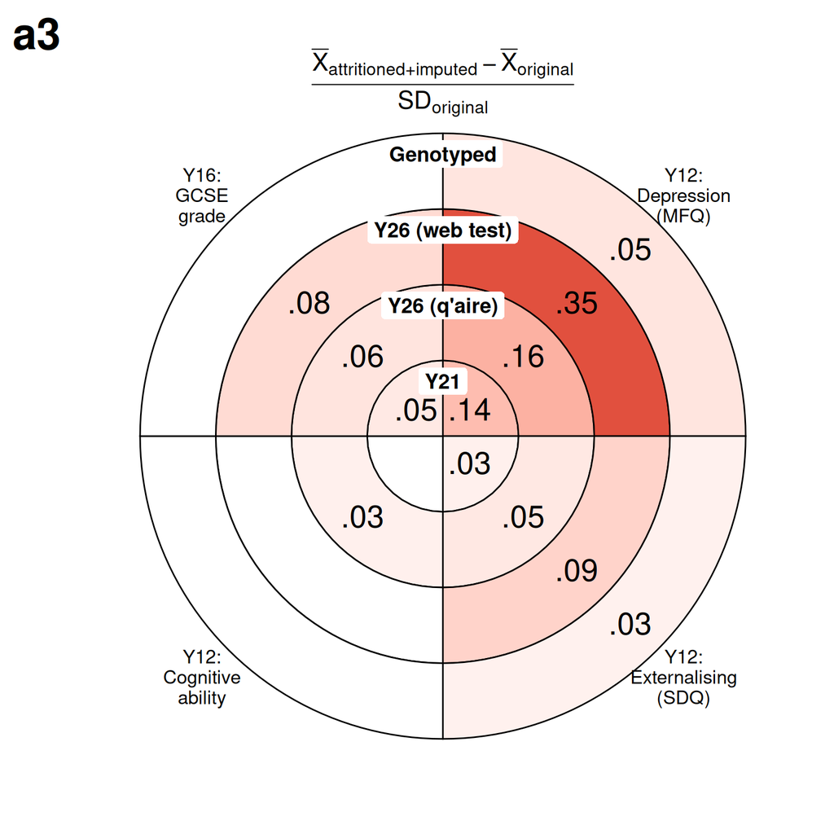

```r
# Create circular heatmap for SMD
heatmap_data_smd = imputed_comparisons_df %>%
  filter(stat == "smd") %>%
  mutate(
    outcome_labeled = rq1y_twin_labels_clean_extrashort[match(dataset, rq1y_twin_labels_clean_extrashort)],
    outcome_labeled = factor(outcome_labeled, levels = rq1y_twin_labels_clean_extrashort),
    Variables_wrapped = str_wrap(variable, width = 8),
    # Set fill value to NA if not significant, otherwise keep original sign
    fill_value = case_when(
      pval_adj < 0.05 ~ y,
      TRUE ~ NA
    )
  ) %>%
  # Use fixed order from rq6y_labels
  mutate(
    variable = factor(variable, levels = rq6y_labels),
    Variables_wrapped = factor(Variables_wrapped, levels = str_wrap(rq6y_labels, width = 8))
  )

 ggplot(heatmap_data_smd, aes(x = Variables_wrapped, y = outcome_labeled)) +
  geom_tile(aes(fill = fill_value),
            color = "black",
            size = 0.5) +
  geom_text(
    aes(label = ifelse(pval_adj < 0.05,
                       gsub("^(-?)0\\.", "\\1.", sprintf("%.2f", y)), ""),
        size = 7.5
    ),
    color = "black"
  ) +
  scale_size_identity() +
  coord_polar(theta = "x", start = 0, direction = 1, clip = "off") +
  scale_fill_gradient2(
    low = "#2166ac",
    mid = "white",
    high = "#d73027",
    midpoint = 0,
    limits = c(-0.4, 0.4),
    na.value = "white",
    guide = "none"
  ) +
  labs(
    subtitle = expression(frac(bar(X)[attritioned + imputed] - bar(X)[original], SD[original])),
    tag = "a3"
  ) +
  theme_minimal() +
  theme(
    axis.text.x = element_text(angle = 0, size = 13, color = "black"),
    axis.text.y = element_blank(),
    axis.title = element_blank(),
    panel.grid = element_blank(),
    panel.background = element_blank(),
    plot.background = element_blank(),
    plot.title = element_blank(),
    plot.subtitle = element_text(hjust = 0.5, size = 17, margin = margin(b = -45)),
    plot.tag = element_text(hjust = 0, vjust = 0, size = 30, face = "bold"),
    plot.tag.position = "topleft"
  ) +
  {
    y_positions = seq_along(levels(heatmap_data_smd$outcome_labeled))
    labels = levels(heatmap_data_smd$outcome_labeled)

    lapply(seq_along(labels), function(i) {
      annotate("label", x = 0.5, y = y_positions[i],
               label = labels[i], size = 5, hjust = 0.5, angle = 0, vjust = -0.12, fontface = "bold",
               fill = "white", label.size = 0)
    })
  }
```

```r
save_plot("8_rq6_circular_heatmap_smd", width = 8, height = 8, trim = TRUE)
```

📊 View Full Resolution SMD Heatmap (PNG)

#### Variance Differences

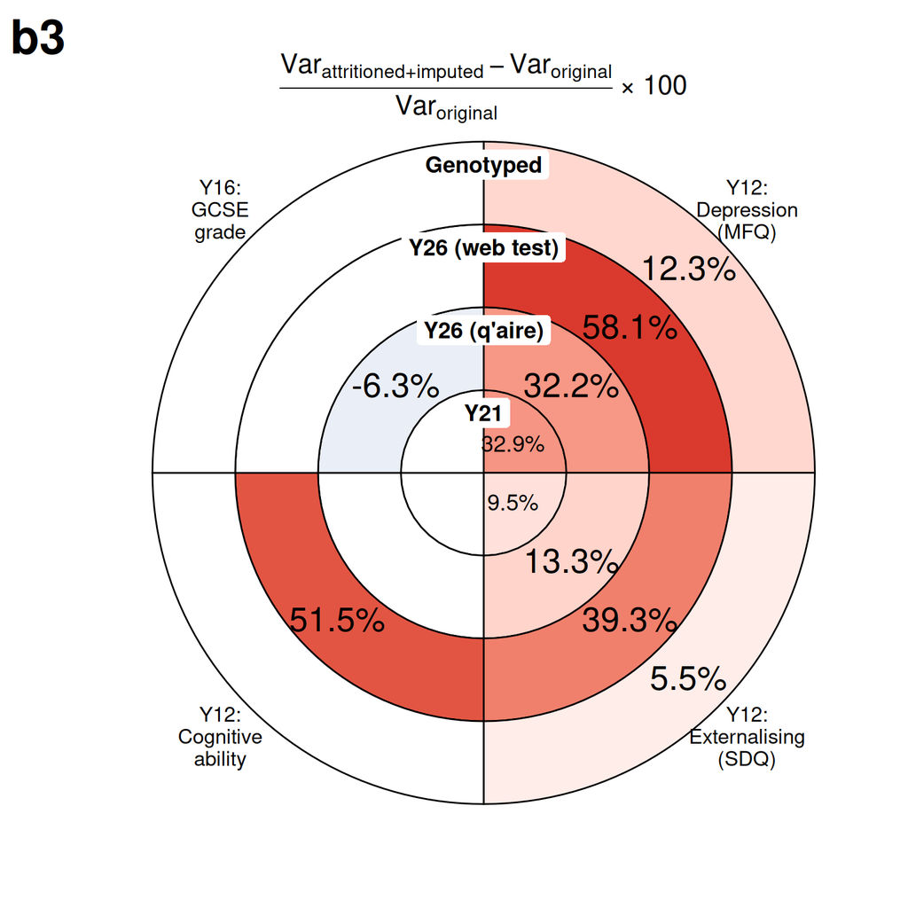

```r
# Create circular heatmap for variance differences
heatmap_data_var = imputed_comparisons_df %>%
  filter(stat == "var") %>%
  mutate(
    outcome_labeled = rq1y_twin_labels_clean_extrashort[match(dataset, rq1y_twin_labels_clean_extrashort)],
    outcome_labeled = factor(outcome_labeled, levels = rq1y_twin_labels_clean_extrashort),
    Variables_wrapped = str_wrap(variable, width = 8),
    # Set fill value to NA if not significant, otherwise keep original sign
    fill_value = case_when(
      pval_adj < 0.05 ~ y,
      TRUE ~ NA
    )
  ) %>%
  # Use fixed order from rq6y_labels
  mutate(
    variable = factor(variable, levels = rq6y_labels),
    Variables_wrapped = factor(Variables_wrapped, levels = str_wrap(rq6y_labels, width = 8))
  )

ggplot(heatmap_data_var,aes(x = Variables_wrapped, y = outcome_labeled)) +
  geom_tile(aes(fill = fill_value),
            color = "black",
            size = 0.5) +
  geom_text(
    aes(label = ifelse(pval_adj < 0.05,
                       paste0(sprintf("%.1f", y * 100), "%"), ""),
        size = ifelse(dataset == "Y21", 5, 7.5)
    ),
    color = "black"
  ) +
  scale_size_identity() +
  coord_polar(theta = "x", start = 0, direction = 1, clip = "off") +
  scale_fill_gradient2(
    low = "#2166ac",
    mid = "white",
    high = "#d73027",
    midpoint = 0,
    limits = c(-0.6, 0.6),
    na.value = "white",
    guide = "none"
  ) +
  labs(
    subtitle = expression(frac(Var[attritioned + imputed] - Var[original], Var[original]) ~ "\u00D7" ~ 100),
    tag = "b3"
  ) +
  theme_minimal() +
  theme(
    axis.text.x = element_text(angle = 0, size = 13, color = "black"),
    axis.text.y = element_blank(),
    axis.title = element_blank(),
    panel.grid = element_blank(),
    panel.background = element_blank(),
    plot.background = element_blank(),
    plot.title = element_blank(),
    plot.subtitle = element_text(hjust = 0.5, size = 17, margin = margin(b = -45)),
    plot.tag = element_text(hjust = 0, vjust = 0, size = 30, face = "bold"),
    plot.tag.position = "topleft"
  ) +
  {
    y_positions = seq_along(levels(heatmap_data_var$outcome_labeled))
    labels = levels(heatmap_data_var$outcome_labeled)

    lapply(seq_along(labels), function(i) {
      annotate("label", x = 0.5, y = y_positions[i],
               label = labels[i], size = 5, hjust = 0.5, angle = 0, vjust = -0.12, fontface = "bold",
               fill = "white", label.size = 0)
    })
  }
```

```r
save_plot("8_rq6_circular_heatmap_var", width = 8, height = 8, trim = TRUE)
```

📊 View Full Resolution Variance Heatmap (PNG)

### Combine all pngs into one plot

```r
library(magick)
gc()
```

```
             used   (Mb) gc trigger    (Mb)   max used    (Mb)
Ncells    6060680  323.7   10138648   541.5   10138648   541.5
Vcells 1124648405 8580.4 1804309182 13765.8 1491966258 11382.8
```

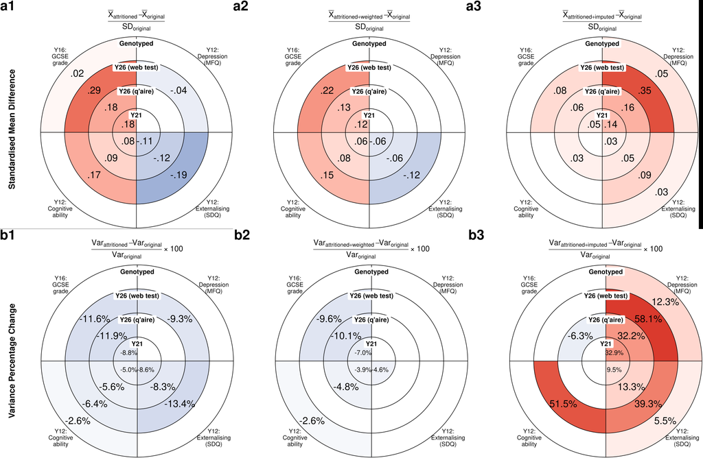

```r
Sys.setenv(MAGICK_MEMORY_LIMIT = "8GiB")
Sys.setenv(MAGICK_MAP_LIMIT = "8GiB")
Sys.setenv(MAGICK_DISK_LIMIT = "16GiB")


# Read all circular plot images
img1 = image_read("plots/pngs/6_rq6_circular_heatmap_smd.png") %>% image_scale("33%")
img2 = image_read("plots/pngs/7_rq7_circular_heatmap_smd.png") %>% image_scale("33%")
img3 = image_read("plots/pngs/8_rq6_circular_heatmap_smd.png") %>% image_scale("33%")
img4 = image_read("plots/pngs/6_rq6_circular_heatmap_var.png") %>% image_scale("33%")
img5 = image_read("plots/pngs/7_rq7_circular_heatmap_var.png") %>% image_scale("33%")
img6 = image_read("plots/pngs/8_rq6_circular_heatmap_var.png") %>% image_scale("33%")


# Combine into rows
row1 = image_append(c(img1, img2, img3))  # SMD plots (a1, a2, a3)
row2 = image_append(c(img4, img5, img6))  # Variance plots (b1, b2, b3)

# Stack rows vertically
combined = image_append(c(row1, row2), stack = TRUE)

# Get dimensions for label positioning
info = image_info(combined)
row_height = info$height / 2

# Add row labels (adjust x and y coordinates as needed)
combined = combined %>%
  image_annotate(
    text = "Standardised Mean Difference",
    size = 50,
    degrees = -90,
    location = paste0("+50+", as.integer(row_height / 2)+450),
    color = "black",
    weight = 700
  ) %>%
  image_annotate(
    text = "Variance Percentage Change",
    size = 50,
    degrees = -90,
    location = paste0("+50+", as.integer(row_height * 1.5)+450),
    color = "black",
    weight = 700
  )

# Save combined image
image_write(combined, "plots/pngs/8_rq6_circular_plots_combined.png")
knitr::include_graphics("plots/pngs/8_rq6_circular_plots_combined.png")
```

📊 View plot

## Correlations

### Plot

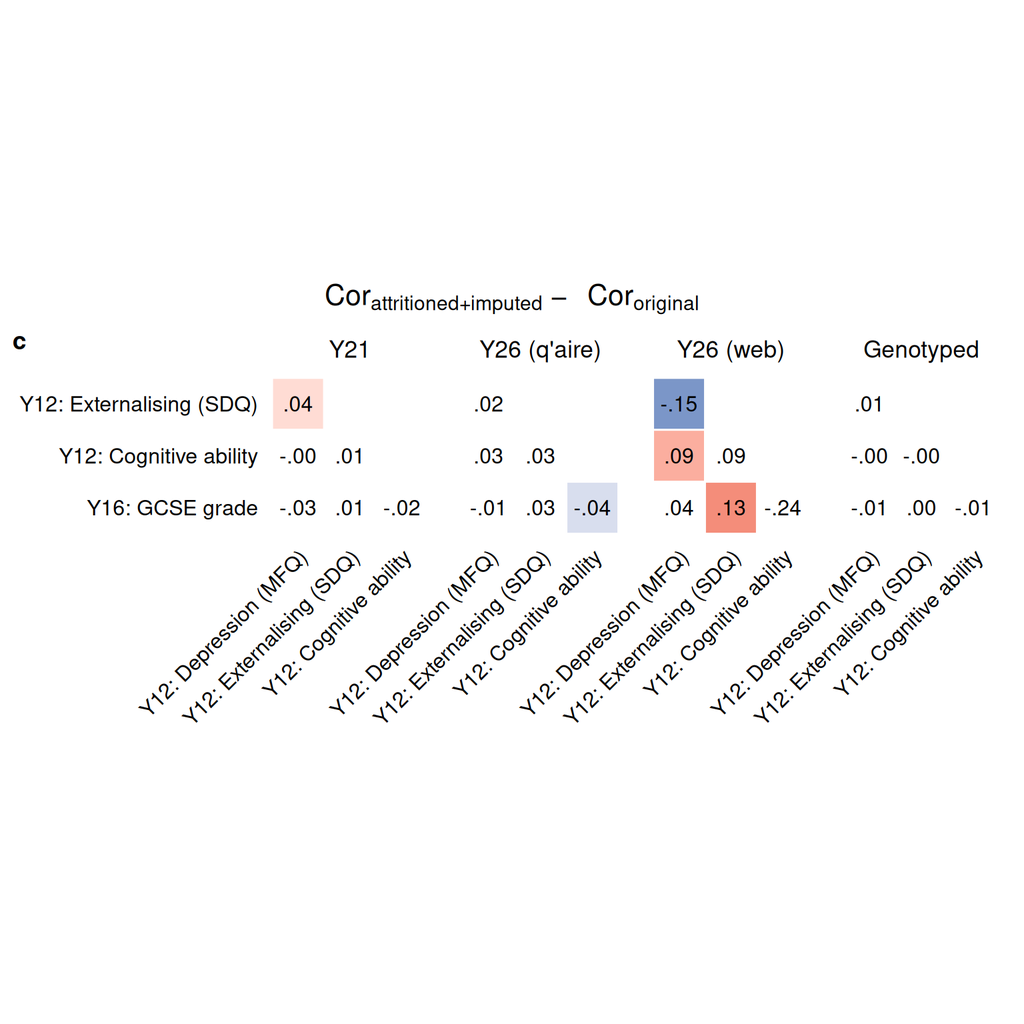

```r
correlation_comparisons = list()

for(tp in seq_along(timepoint_names)){

  timepoint_name = timepoint_names[tp]

  # Get all imputations for this timepoint
  tp_pattern = paste0("^", timepoint_name)
  tp_indices = grep(tp_pattern, names(boot_compare_results))

  # Extract results for each imputation
  tp_results = boot_compare_results[tp_indices]

  # Extract correlation results across all imputations
  cor_data = lapply(tp_results, function(imp) {
    # imp$cor_resid is a list of bootstrap iterations
    sapply(imp$cor_resid, function(boot_iter) boot_iter)
  })

  # Combine all bootstrap samples across imputations
  all_cors = do.call(cbind, cor_data)

  # Calculate summary statistics
  cor_summary = apply(all_cors, 1, function(xx) .mean_qi_pd(xx))
  cor_summary = do.call(rbind.data.frame, cor_summary)
  cor_summary$x_var = x_var
  cor_summary$y_var = y_var
  cor_summary = cor_summary[cor_summary$x_var != cor_summary$y_var,]  # Remove diagonal
  cor_summary$pval_adj = stats::p.adjust(cor_summary$pval, method = "holm")

  correlation_comparisons[[tp]] = cor_summary
}

library(patchwork)

rq1y_twin_labels_clean_extrashort2 = rq1y_twin_labels_clean_extrashort
rq1y_twin_labels_clean_extrashort2[3] = "Y26 (web)"

plots = lapply(1:length(correlation_comparisons), function(i) {
  plot_lower_triangular_matrix2(
    data = correlation_comparisons[[i]],
    variables = rq6y,
    labels = rq6y_labels,
    x_var_col = "x_var",
    y_var_col = "y_var",
    value_col = "y",
    p_col = "pval_adj",
    p_threshold = 0.05,
    show_values = TRUE,
    text_size = 4.2,
    title = rq1y_twin_labels_clean_extrashort2[i],
    caption = NULL,
    method = "none"
  ) +
  labs(tag = if (i == 1) "c" else NULL) + # one panel letter per row
  theme(
    plot.title        = element_text(hjust=0.5),
    axis.text         = element_text(color = "black"),
    plot.background   = element_blank(),
    panel.background  = element_blank(),
    legend.background = element_blank(),
    plot.tag          = element_text(size = 14, face = "bold"),
    plot.tag.position = c(0, 1),
    axis.text.y       = if (i > 1) element_blank() else element_text(size = 12),
    axis.text.x       = element_text(size = 12)
  )
})

patchwork::wrap_plots(
  plots,
  ncol = 4) +
  plot_annotation(
    title = expression(Cor[attritioned + imputed] ~ - ~ ~ Cor[original]),
    theme = theme(
      plot.title    = element_text(hjust = 0.5, size = 16, face = "bold"),
      plot.subtitle = element_text(hjust = 0.5, size = 13)
      )
  )
```

```r
save_plot(
  "8_rq6_correlations", width = 9, height = NA, trim = TRUE, trim_margin = 0)
```

📊 View Full Resolution Correlation Plots (PNG)

### GT Results table

```r
cor_table = bind_rows(correlation_comparisons, .id = "timepoint") %>%
  mutate(
    dataset = rq1y_twin_labels_clean_extrashort[as.numeric(timepoint)],
    x_var_label = rq6y_labels[match(x_var, rq6y)],
    y_var_label = rq6y_labels[match(y_var, rq6y)],
    pair = paste(x_var_label, "×", y_var_label)
  ) %>%
  select(dataset, pair, y, ymin, ymax, pval, pval_adj) %>%
  gt(groupname_col = "dataset") %>%
  tab_options(
    table.width = px(800)
  ) %>%

  # Rename columns
  cols_label(
    pair = "Variable Pair",
    y = "Est",
    ymin = "LB",
    ymax = "UB",
    pval = md("p<sub>unadj</sub>"),
    pval_adj = md("p<sub>adj</sub>")
  ) %>%

  # Create column spanner
  tab_spanner(
    label = "Correlation Difference",
    columns = c(y, ymin, ymax, pval, pval_adj)
  ) %>%

  # Format numbers
  fmt(
    columns = c(y, ymin, ymax),
    fns = function(x) {gbtoolbox::apa_num(x, n_decimal_places = 3)}
  ) %>%
  fmt(
    columns = c(pval, pval_adj),
    fns = function(x) {gbtoolbox::apa_num(x, n_decimal_places = 3)}
  ) %>%

  # Styling - uniform font size
  tab_style(
    style = cell_text(size = px(10)),
    locations = cells_column_spanners()
  ) %>%
  tab_style(
    style = cell_text(size = px(10)),
    locations = cells_body()
  ) %>%
  tab_style(
    style = cell_text(size = px(10), align = "center"),
    locations = cells_row_groups()
  ) %>%
  tab_style(
    style = cell_text(size = px(10)),
    locations = cells_column_labels()
  ) %>%
  tab_style(
    style = cell_text(size = px(10)),
    locations = cells_footnotes()
  ) %>%

  # Highlight significant results - positive effects (light green)
  tab_style(
    style = cell_fill(color = "#d5e8d4"),
    locations = cells_body(
      columns = c(y, ymin, ymax, pval, pval_adj),
      rows = pval_adj < 0.05 & y > 0
    )
  ) %>%

  # Highlight significant results - negative effects (light red)
  tab_style(
    style = cell_fill(color = "#f8cecc"),
    locations = cells_body(
      columns = c(y, ymin, ymax, pval, pval_adj),
      rows = pval_adj < 0.05 & y < 0
    )
  ) %>%

  # Add footnotes
  tab_footnote(
    footnote = md("<em>Note.</em> Est = Estimate, LB = Lower Bound 95% Confidence Interval, UB = Upper Bound 95% Confidence Interval. Significant (p<sub>Bonferroni-Holm</sub>) effects are highlighted in green (increases) or red (decreases)."),
    placement = "right"
  ) %>%
  tab_footnote(
    footnote = "P values are Bonferroni-Holm adjusted within each attrition timepoint",
    locations = cells_column_labels(columns = pval_adj),
    placement = "right"
  ) %>%
  tab_footnote(
    footnote = md("Correlation difference = Cor<sub>attritioned + imputed</sub> - Cor<sub>original</sub>"),
    locations = cells_column_spanners(spanners = "Correlation Difference"),
    placement = "right"
  ) %>%
  opt_footnote_marks(marks = c("*", "†", "‡"))

cor_table
```

| Variable Pair | Correlation Difference* Est | Correlation Difference* LB | Correlation Difference* UB | Correlation Difference* p<sub>unadj</sub> | Correlation Difference* p<sub>adj</sub>† |
| --- | --- | --- | --- | --- | --- |
| Y21 |  |  |  |  |  |
| Y12: Externalising (SDQ) × Y12: Depression (MFQ) | .040 | .015 | .066 | .003 | .016 |
| Y12: Cognitive ability × Y12: Depression (MFQ) | -.003 | -.031 | .026 | .836 | .925 |
| Y16: GCSE grade × Y12: Depression (MFQ) | -.028 | -.056 | -.002 | .037 | .184 |
| Y12: Cognitive ability × Y12: Externalising (SDQ) | .015 | -.013 | .042 | .308 | .925 |
| Y16: GCSE grade × Y12: Externalising (SDQ) | .011 | -.012 | .034 | .340 | .925 |
| Y16: GCSE grade × Y12: Cognitive ability | -.018 | -.038 | .001 | .065 | .262 |
| Y26 (q'aire) |  |  |  |  |  |
| Y12: Externalising (SDQ) × Y12: Depression (MFQ) | .017 | -.011 | .046 | .248 | .496 |
| Y12: Cognitive ability × Y12: Depression (MFQ) | .028 | -.006 | .059 | .108 | .324 |
| Y16: GCSE grade × Y12: Depression (MFQ) | -.012 | -.043 | .018 | .426 | .496 |
| Y12: Cognitive ability × Y12: Externalising (SDQ) | .033 | .002 | .066 | .037 | .147 |
| Y16: GCSE grade × Y12: Externalising (SDQ) | .034 | .007 | .061 | .010 | .050 |
| Y16: GCSE grade × Y12: Cognitive ability | -.044 | -.068 | -.020 | .000 | .000 |
| Y26 (web test) |  |  |  |  |  |
| Y12: Externalising (SDQ) × Y12: Depression (MFQ) | -.146 | -.253 | -.056 | .000 | .001 |
| Y12: Cognitive ability × Y12: Depression (MFQ) | .092 | .015 | .170 | .016 | .048 |
| Y16: GCSE grade × Y12: Depression (MFQ) | .044 | -.017 | .107 | .174 | .174 |
| Y12: Cognitive ability × Y12: Externalising (SDQ) | .091 | .010 | .173 | .026 | .052 |
| Y16: GCSE grade × Y12: Externalising (SDQ) | .129 | .074 | .189 | .000 | .000 |
| Y16: GCSE grade × Y12: Cognitive ability | -.238 | -.296 | -.182 | .000 | .000 |
| Genotyped |  |  |  |  |  |
| Y12: Externalising (SDQ) × Y12: Depression (MFQ) | .011 | -.007 | .028 | .233 | .934 |
| Y12: Cognitive ability × Y12: Depression (MFQ) | -.003 | -.022 | .017 | .803 | 1.000 |
| Y16: GCSE grade × Y12: Depression (MFQ) | -.013 | -.032 | .005 | .158 | .880 |
| Y12: Cognitive ability × Y12: Externalising (SDQ) | -.003 | -.020 | .015 | .744 | 1.000 |
| Y16: GCSE grade × Y12: Externalising (SDQ) | .001 | -.014 | .015 | .944 | 1.000 |
| Y16: GCSE grade × Y12: Cognitive ability | -.009 | -.022 | .003 | .147 | .880 |

*Note.* Est = Estimate, LB = Lower Bound 95% Confidence Interval, UB = Upper Bound 95% Confidence Interval. Significant (p<sub>Bonferroni-Holm</sub>) effects are highlighted in green (increases) or red (decreases).  
* Correlation difference = Cor<sub>attritioned + imputed</sub> - Cor<sub>original</sub>  
† P values are Bonferroni-Holm adjusted within each attrition timepoint

### Combine all correlation plots into one PNG

```r
library(magick)
gc()
```

```
             used   (Mb) gc trigger    (Mb)   max used    (Mb)
Ncells    6108030  326.3   10138648   541.5   10138648   541.5
Vcells 1124857045 8582.0 1804309182 13765.8 1491966258 11382.8
```

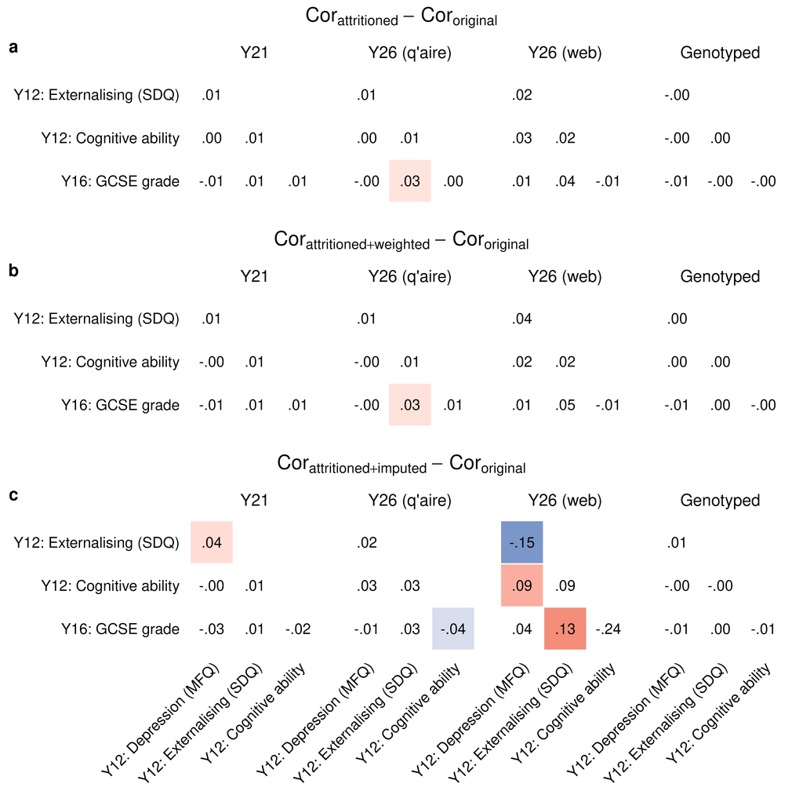

```r
Sys.setenv(MAGICK_MEMORY_LIMIT = "8GiB")
Sys.setenv(MAGICK_MAP_LIMIT = "8GiB")
Sys.setenv(MAGICK_DISK_LIMIT = "16GiB")

# Read all correlation plot images
img1 = image_read("plots/pngs/6_rq6_correlations.png")
img2 = image_read("plots/pngs/7_rq7_correlations.png")
img3 = image_read("plots/pngs/8_rq6_correlations.png")

# Stack all plots vertically
combined = image_append(c(img1, img2, img3), stack = TRUE)

# Save combined image
image_write(combined, "plots/pngs/8_rq6_correlations_combined.png")
knitr::include_graphics("plots/pngs/8_rq6_correlations_combined.png")
```

🖼️ Image #1

## ACE Comparison

```r
# Extract ACE estimates and differences from all datasets
ace_estimates_list = list()
ace_differences_list = list()

for(tp in seq_along(timepoint_names)){

  timepoint_name = timepoint_names[tp]

  # Get all imputations for this timepoint
  tp_pattern = paste0("^", timepoint_name)
  tp_indices = grep(tp_pattern, names(boot_compare_results))

  # Extract results for each imputation
  tp_results = boot_compare_results[tp_indices]

  # Process ACE results across all imputations
  ace_results = lapply(tp_results, function(imp) {
    lapply(imp$ace, function(x) x)
  })

  # Flatten and process
  ace_results = unlist(ace_results, recursive = FALSE)
  ace_results = lapply(ace_results, function(x) do.call(rbind, x))
  ace_results = do.call(rbind, ace_results) %>%
    filter(par %in% c("a","c", "e"))

  ace_results_summary = ace_results %>%
    group_by(par, name, sex, group) %>%
    summarise(
      .mean_qi_pd(value),
      .groups = "drop"
    )

  # Separate estimates and differences
  ace_estimates_list[[tp]] = ace_results_summary %>%
    filter(group != "diff")

  ace_differences_list[[tp]] = ace_results_summary %>%
    filter(group == "diff")

  # Add dataset identifier
  ace_estimates_list[[tp]]$dataset = rq1y_twin1[tp]
  ace_differences_list[[tp]]$dataset = rq1y_twin1[tp]
}
# Combine into single dataframes
ace_estimates = do.call(rbind, ace_estimates_list)
ace_differences = do.call(rbind, ace_differences_list)

# Add readable dataset labels
ace_estimates$dataset_label = rq1y_twin_labels_clean[match(ace_estimates$dataset, rq1y_twin1)]
ace_differences$dataset_label = rq1y_twin_labels_clean[match(ace_differences$dataset, rq1y_twin1)]
```

### Table - ACE estimates

```r
ace_estimates %>%
  filter(par %in% c("a", "c", "e")) %>%
  select(-starts_with("."), -n, -pd, -pval) %>%
  mutate(
    name_clean = rq6y_labels[match(name, rq6y_prefix)],
    group = case_when(
      group == "df1" ~ "Imputed",                                             # .boot_compare_df(df1 = attritioned + imputed, df2 = original) in 8_rq6_2
      group == "df2" ~ "Original",
      TRUE ~ group
    )
  ) %>%
  pivot_wider(
    id_cols = c(dataset_label, name_clean, par, sex),
    names_from = group,
    values_from = c(y, ymin, ymax),
    names_sep = "_"
  ) %>%
  select(dataset_label, name_clean, par, sex,
         y_Original, ymin_Original, ymax_Original,
         y_Imputed, ymin_Imputed, ymax_Imputed) %>%
  arrange(sex, dataset_label, name_clean, par) %>%
  mutate(par = toupper(par)) %>%
  gt(groupname_col = "sex") %>%
  fmt_number(decimals = 3) %>%
  tab_row_group(
    label = "Male",
    rows = sex == "male"
  ) %>%
  tab_row_group(
    label = "Female",
    rows = sex == "female"
  ) %>%
  cols_hide(sex) %>%
  cols_label(
    dataset_label = "Dataset",
    name_clean = "Variable",
    par = "",
    y_Original = "Est",
    ymin_Original = "Lower",
    ymax_Original = "Upper",
    y_Imputed = "Est",
    ymin_Imputed = "Lower",
    ymax_Imputed = "Upper"
  ) %>%
  tab_spanner(
    label = "Original",
    columns = c(y_Original, ymin_Original, ymax_Original)
  ) %>%
  tab_spanner(
    label = "Attritioned + Imputed",
    columns = c(y_Imputed, ymin_Imputed, ymax_Imputed)
  ) %>%
  tab_options(
    table.font.size = px(9)
  )
```

| Dataset | Variable |  | Original Est | Original Lower | Original Upper | Attritioned + Imputed Est | Attritioned + Imputed Lower | Attritioned + Imputed Upper |
| --- | --- | --- | --- | --- | --- | --- | --- | --- |
| Female |  |  |  |  |  |  |  |  |
| Genotyped | Y12: Cognitive ability | A | 0.427 | 0.310 | 0.547 | 0.516 | 0.376 | 0.661 |
| Genotyped | Y12: Cognitive ability | C | 0.272 | 0.163 | 0.377 | 0.175 | 0.039 | 0.307 |
| Genotyped | Y12: Cognitive ability | E | 0.301 | 0.272 | 0.333 | 0.309 | 0.278 | 0.342 |
| Genotyped | Y12: Depression (MFQ) | A | 0.218 | 0.002 | 0.435 | 0.270 | 0.035 | 0.485 |
| Genotyped | Y12: Depression (MFQ) | C | 0.207 | 0.025 | 0.378 | 0.178 | 0.000 | 0.372 |
| Genotyped | Y12: Depression (MFQ) | E | 0.575 | 0.505 | 0.645 | 0.552 | 0.478 | 0.628 |
| Genotyped | Y12: Externalising (SDQ) | A | 0.494 | 0.394 | 0.550 | 0.512 | 0.437 | 0.565 |
| Genotyped | Y12: Externalising (SDQ) | C | 0.013 | 0.000 | 0.092 | 0.005 | 0.000 | 0.065 |
| Genotyped | Y12: Externalising (SDQ) | E | 0.493 | 0.449 | 0.540 | 0.482 | 0.435 | 0.534 |
| Genotyped | Y16: GCSE grade | A | 0.544 | 0.462 | 0.631 | 0.572 | 0.485 | 0.665 |
| Genotyped | Y16: GCSE grade | C | 0.347 | 0.263 | 0.427 | 0.317 | 0.227 | 0.401 |
| Genotyped | Y16: GCSE grade | E | 0.109 | 0.096 | 0.122 | 0.110 | 0.097 | 0.124 |
| Y21 (TEDS21 phase-1 questionnaire) | Y12: Cognitive ability | A | 0.428 | 0.312 | 0.549 | 0.477 | 0.331 | 0.628 |
| Y21 (TEDS21 phase-1 questionnaire) | Y12: Cognitive ability | C | 0.271 | 0.159 | 0.379 | 0.200 | 0.063 | 0.331 |
| Y21 (TEDS21 phase-1 questionnaire) | Y12: Cognitive ability | E | 0.301 | 0.271 | 0.332 | 0.322 | 0.285 | 0.363 |
| Y21 (TEDS21 phase-1 questionnaire) | Y12: Depression (MFQ) | A | 0.219 | 0.001 | 0.435 | 0.204 | 0.000 | 0.435 |
| Y21 (TEDS21 phase-1 questionnaire) | Y12: Depression (MFQ) | C | 0.205 | 0.021 | 0.377 | 0.298 | 0.103 | 0.470 |
| Y21 (TEDS21 phase-1 questionnaire) | Y12: Depression (MFQ) | E | 0.576 | 0.508 | 0.643 | 0.498 | 0.421 | 0.576 |
| Y21 (TEDS21 phase-1 questionnaire) | Y12: Externalising (SDQ) | A | 0.493 | 0.396 | 0.549 | 0.538 | 0.442 | 0.598 |
| Y21 (TEDS21 phase-1 questionnaire) | Y12: Externalising (SDQ) | C | 0.012 | 0.000 | 0.091 | 0.009 | 0.000 | 0.090 |
| Y21 (TEDS21 phase-1 questionnaire) | Y12: Externalising (SDQ) | E | 0.494 | 0.450 | 0.541 | 0.453 | 0.401 | 0.507 |
| Y21 (TEDS21 phase-1 questionnaire) | Y16: GCSE grade | A | 0.544 | 0.461 | 0.631 | 0.586 | 0.493 | 0.685 |
| Y21 (TEDS21 phase-1 questionnaire) | Y16: GCSE grade | C | 0.347 | 0.263 | 0.426 | 0.305 | 0.207 | 0.395 |
| Y21 (TEDS21 phase-1 questionnaire) | Y16: GCSE grade | E | 0.109 | 0.096 | 0.122 | 0.109 | 0.095 | 0.124 |
| Y26 (CATSLife web tests) | Y12: Cognitive ability | A | 0.427 | 0.309 | 0.545 | 0.384 | 0.114 | 0.597 |
| Y26 (CATSLife web tests) | Y12: Cognitive ability | C | 0.272 | 0.162 | 0.381 | 0.149 | 0.000 | 0.371 |
| Y26 (CATSLife web tests) | Y12: Cognitive ability | E | 0.301 | 0.271 | 0.332 | 0.467 | 0.385 | 0.559 |
| Y26 (CATSLife web tests) | Y12: Depression (MFQ) | A | 0.220 | 0.004 | 0.431 | 0.229 | 0.000 | 0.472 |
| Y26 (CATSLife web tests) | Y12: Depression (MFQ) | C | 0.206 | 0.028 | 0.379 | 0.164 | 0.000 | 0.368 |

[output cut: 68 more lines]